# Required Packages:

- NumPy: For numerical computing
- Matplotlib: For visualizing solution to ODE and its applications
- Jupyter Lab: For running Jupyter notebooks.

All these packages are mentioned in `requirements.txt`

## Some more requirements:

- A piece of paper (Graph paper would be good).
- A pencil/pen/sketchpen or anything you can use to draw.
- Geometry box (Protractor and 15cm scale)
- Calculator

```python
import numpy as np
import matplotlib.pyplot as plt
from solver import ivp
```

# What is an ODE?

Ordinary Differential Equation (ODEs), is a family of differential equations, which relates an unknown function of dependent variable with its derivatives. These equations are termed as ODE to distinguish then with Partial Differential Equations (PDEs).

## Examples of ODE:

$$ \frac{dy}{dx}+y=0,\qquad\frac{dy}{dx}+xy=0,\qquad\frac{dy}{dx}=\frac{2}{\sqrt{\pi}}e^{-x^2},\qquad\frac{d^2y}{dx^2}+\omega^2y=0,\space\text{etc. are some examples of ODEs} $$

# Solving ODEs numerically:

We will first understand first-order ODEs using Euler's method, then move on to more advanced methods such as Midpoint method, Heun's method and Runge-Kutta method of order 4.

## Need for solving differential equations numerically:

Before understanding how to solve differential equations numerically, we need to understand why do we need to do this in the first place.

Simple equations like: $\frac{dy}{dx}=y$ or $\frac{d^2y}{dx^2}-3\frac{dy}{dx}+2y=0$ can be solved analytically, and their solutions are: $y=Ae^x$ and $A_{1}e^{2x}+A_{2}e^x$, where $A,A_1,A_2$ are arbitrary constants, which can be determined by giving appropriate conditions. The way these conditions are giving further create a new class of problems known as:

1. Initial Value Problems (IVP): This notebook focuses on techniques to solve IVP problems.
2. Boundary Value Problems (BVP): Another notebook will focus on techniques to solve BVP problems.

But anyway, these equations can be solved, but the equation $\frac{dy}{dx}=\frac{2}{\sqrt{\pi}}e^{-x^2}$ cannot be solved analytically because antiderivative of $e^{-x^2}$ cannot be expressed in terms of elementary functions. For this we could obviously use numerical integration techniques, but then the logistic equation with Allee's modification solved analytically looks very complex and it cannot be expressed as explicit function between $x$ and $y$. This creates a need for solving differential equations numerically.

## Vector fields:

Now again I will have to hold on the techniques to solve ODEs numerically and divert your attention to an interesting concept known as vector fields. The concept of vector field will make it easier to understand the methods.

Say we have a differential equation: $$ \frac{dy}{dx}=f(x, y) $$ Now this equation gives the slope of a curve at any point in space i.e. at $(x, y)$. $$ \tan\theta=f(x, y) $$ Using this $\theta$ just plot a small line in that direction on the point $(x, y)$ on the graph. This will give you the vector field.

Below I will plot the vector field for $\frac{dy}{dx}=2x$.

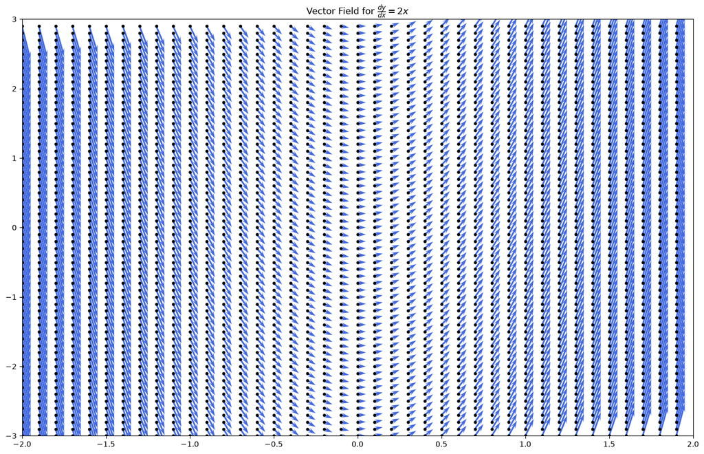

```python
x = np.arange(-2, 2, 0.1)
y = np.arange(-3, 3, 0.1)
X, Y = np.meshgrid(x, y)

func = lambda x, y: 2*x

U = 0.01*np.ones_like(X)
V = func(X, Y)*0.01

fig, ax = plt.subplots(figsize=(16, 10))

ax.set_xlim(-2, 2)
ax.set_ylim(-3, 3)
ax.quiver(X, Y, U, V, color="royalblue", scale=0.8, headaxislength=3.5)
ax.scatter(X, Y, s=10, color="black")
ax.set_title(r"$\text{Vector Field for }\frac{dy}{dx}=2x$")
plt.show()
```

The analytical solution to $\frac{dy}{dx}=2x$ is $y=x^2+c\qquad\text{Where }c\text{ is an arbitary constant.}$

Now ask yourself a question, what does the graph of $x^2+c\qquad\forall c\in\mathbb{R}$ look like? It is a parabola, now look at our vector field, doesn't it look like parabola? If not then take a look below!

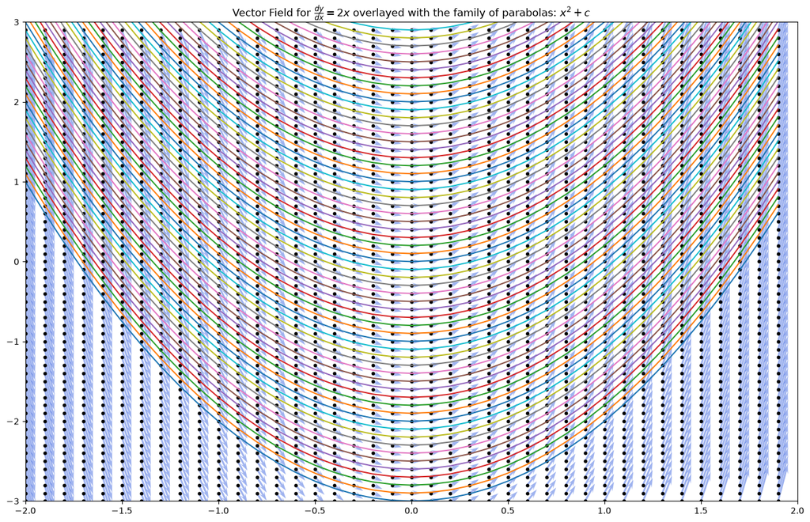

```python
x = np.arange(-2, 2, 0.1)
y = np.arange(-3, 3, 0.1)
X, Y = np.meshgrid(x, y)

func = lambda x, y: 2*x

U = 0.01*np.ones_like(X)
V = func(X, Y)*0.01

fig, ax = plt.subplots(figsize=(16, 10))

ax.set_xlim(-2, 2)
ax.set_ylim(-3, 3)
ax.quiver(X, Y, U, V, color="royalblue", scale=0.8, headaxislength=3.5, alpha=0.5)
ax.scatter(X, Y, s=10, color="black")

for c in y:
    ax.plot(x, x**2+c)

ax.set_title(r"$\text{Vector Field for }\frac{dy}{dx}=2x\text{ overlayed with the family of parabolas: }x^2+c$")
plt.show()
```

It is fairly visible that the vector field represents parabola. Just follow one curve and let the vector guide you!

Notice how the curves are drawn. Start at any one point, the vector at that point shows how to go ahead, travel in that direction, then reach the next point and see how the vector that this point tells go ahead and repeat.

This is the important motivation behind Euler's method!

## Solving first order ODEs using Euler's method:

Now that we know the problem in front of us and the motivation, let us start with the solution, with the simplest method, that is the Euler's method. $$\begin{align*} &\text{A first order ODE is of form:}\\ &\frac{dy}{dx}=f(x,y)\\ &\text{Now that this is an IVP, the area of interest is from }a\text{ to }b\text{ with }y(a)=y_0\\ &\text{From here we have to move forward where the vector is pointing to, we know that from slope. Now to move in direction of that vector we need to}\\ &\text{extend the line we drew to draw the vector field. This line is just local approximation on a function. We do so by using the formula:}\\ &y(x)=y(x_0)+f(x_0, y(x_0))(x-x_0)\\ &\text{To find approximation at }x=x_1\text{ we use the above equation.}\\ &\therefore y(x_1)=y(x_0)+f(x_0, y(x_0))(x_1-x_0)\\ &\therefore y(x_1)=y(x_0)+f(x_0, y(x_0))\Delta x\qquad \Delta x=x_1-x_0\\ &\text{We can apply the same concept here, first will divide whole area of interest into }N\text{ equally spaced interval with step size }h.\\ &\text{We will then approximate value of }y\text{ at the next step and keep on doing this till we reach the end of interval. As }h\rightarrow 0\text{, the approximation}\\ &\text{gets better.}\\ &h=\frac{b-a}{N}\\ &y(a+(i+1)h)=y(a+ih)+f(a+ih, y(a+ih))\Delta x\implies y(a+(i+1)h)=y(a+ih)+f(a+ih, y(a+ih))h\qquad\forall 0\leq i<N\\ &\text{A table of values:}\\ &\begin{array} &x&&y\\ \hline a&&y(a)\\ a+h&&y(a)+f(a, y(a))h\\ a+2h&&y(a+h)+f(a+h, y(a+h))h\\ \vdots&&\vdots\\ a+Nh=b&&y(a+(N-1)h)+f(a+(N-1)h, y(a+(N-1)h))h \end{array} \end{align*}$$

This is simply how Euler's method works!

Euler's method gives global error in order of $\mathcal{O}(h)$. This means the error decreases linearly as we decrease step size.

Other methods are somewhat variations of Euler's method.

## Solving first order ODEs using Midpoint method:

Euler's method gives global error at $\mathcal{O}(h)$, so we need some more better methods.

Midpoint method gives global error at $\mathcal{O}(h^2)$.

Here, instead of trusting the slope at the beginning, we find the slope at the center.

The reason we use center here is because, central difference gives more accurate approximation for differentiation, rather than forward or backward difference.

$$\begin{align*} &\text{A first order ODE is of form:}\\ &\frac{dy}{dx}=f(x,y)\\ &\text{Now that this is an IVP, the area of interest is from }a\text{ to }b\text{ with }y(a)=y_0\\ &\text{We again divide our area of interest into }N\text{ equal parts with stepsize }h\\ &\text{We again start local approximation, but with a slight modification:}\\ &y(a+(i+1)h)=y(a+ih)+hf\left(a+ih+\frac{h}{2}, y\left(a+ih+\frac{h}{2}\right)\right)\qquad\forall 0\leq i<N\\ &y\left(a+ih+\frac{h}{2}\right)=y(a+ih)+\frac{h}{2}f(a+ih, y(a+ih))\\ &\text{A table of values:}\\ &\begin{array} &x&&y\\ \hline a&&y(a)\\ a+h&&y(a)+f\left(a+\frac{h}{2}, y\left(a+\frac{h}{2}\right)\right)h\\ a+2h&&y(a+h)+f\left(a+h+\frac{h}{2}, y\left(a+h+\frac{h}{2}\right)\right)h\\ \vdots&&\vdots\\ a+Nh=b&&y(a+(N-1)h)+f\left(a+(N-1)h+\frac{h}{2}, y\left(a+(N-1)h+\frac{h}{2}\right)\right)h \end{array} \end{align*}$$

## Solving first order ODEs using Heun's method:

This method also gives global error in $\mathcal{O}(h^{2})$.

Here, we find 2 slopes:

1. At the beginning.
2. At the end.

Then we take their arithmetic mean and use that for finding next value of $y$. Quite simple method!

$$\begin{align*} &\text{A first order ODE is of form:}\\ &\frac{dy}{dx}=f(x,y)\\ &\text{Now that this is an IVP, the area of interest is from }a\text{ to }b\text{ with }y(a)=y_0\\ &\text{We again divide our area of interest into }N\text{ equal parts with stepsize }h\\ &k_1=f(a+ih, y(a+ih))\\ &k_2=f(a+(i+1)h, y(a+(i+1)h))\qquad\text{Here,}\quad y(a+(i+1)h)=y(a+ih)+hf(a+ih, y(a+ih))\\ &y(a+(i+1)h)=y(a+ih)+h\left(\frac{k_1+k_2}{2}\right)\qquad\forall0\leq i< N\\ &\text{A table of values:}\\ &\begin{array} &x&&k_1&&k_2&&y\\ \hline a&&-&&-&&y(a)\\ a+h&&f(a, y(a))&&f(a+h, y(a+h))&&y(a)+h\left(\frac{k_1+k_2}{2}\right)\\ a+2h&&f(a+h, y(a+h))&&f(a+2h, y(a+2h))&&y(a+h)+h\left(\frac{k_1+k_2}{2}\right)\\ \vdots&&\vdots&&\vdots&&\vdots\\ a+Nh=b&&f(a+(N-1)h, y(a+(N-1)h))&&f(b, y(b))&&y(a+(N-1)h)+h\left(\frac{k_1+k_2}{2}\right) \end{array} \end{align*}$$

## Solving first order ODEs using RK4 method:

Runge-Kutta method of order 4 (RK4) is a very accurate, industry standard method, which has global error of order $\mathcal{O}(h^4)$

Just like how we needed to find $k_1, k_2$ in Heun's method, we have to find $k_1, k_2, k_3, k_4$ here. Note that this is not of order 4 because we are using 4 slopes, but because it's error is of order $\mathcal{O}(h^4)$.

The 4 slopes are:

1. At the beginning.
2. At the midpoint, using slope found in previous step
3. Using slope found in previous step to again find a better approximation at midpoint.
4. At the end, using slope found in previous step.

Then, we take their weighted mean and use that to find the next value of $y$. Again such a simple method!

$$\begin{align*} &\text{A first order ODE is of form:}\\ &\frac{dy}{dx}=f(x,y)\\ &\text{Now that this is an IVP, the area of interest is from }a\text{ to }b\text{ with }y(a)=y_0\\ &\text{We again divide our area of interest into }N\text{ equal parts with stepsize }h\\ &k_1=f(a+ih, y(a+ih))\\ &k_2=f\left(a+ih+\frac{h}{2}, y\left(a+ih+\frac{h}{2}\right)\right)\qquad\text{Here,}\quad y\left(a+ih+\frac{h}{2}\right)=y(a+ih)+k_1\frac{h}{2}\\ &k_3=f\left(a+ih+\frac{h}{2}, y\left(a+ih+\frac{h}{2}\right)\right)\qquad\text{Here,}\quad y\left(a+ih+\frac{h}{2}\right)=y(a+ih)+k_2\frac{h}{2}\\ &k_4=f(a+(i+1)h, y(a+(i+1)h))\qquad\text{Here,}\quad y(a+(i+1)h)=y(a+ih)+k_3h\\ &\text{Now making a table with }x,k_1,k_2,k_3,k_4\text{ and }y\text{ would take more space and cause formatting errors, so I'll just make a table for }x\text{ and }y\\ &\begin{array} &x&&y\\ \hline a&&y(a)\\ a+h&&y(a)+h\left(\frac{k_1+2k_2+2k_3+k_4}{6}\right)\\ a+2h&&y(a+h)+h\left(\frac{k_1+2k_2+2k_3+k_4}{6}\right)\\ \vdots&&\vdots\\ a+Nh=b&&y(a+(N-1)h)+h\left(\frac{k_1+2k_2+2k_3+k_4}{6}\right) \end{array} \end{align*}$$

## An example:

Now let us take a look at how the 4 methods gives us the solution.

We will consider the simple ODE: $\frac{dy}{dx}=\cos(x)$, with $(0, 0)$ lying on the solution curve in the region $0\leq x<2\pi$ with stepsize $0.1$. Analytically the solution is $\sin(x)$

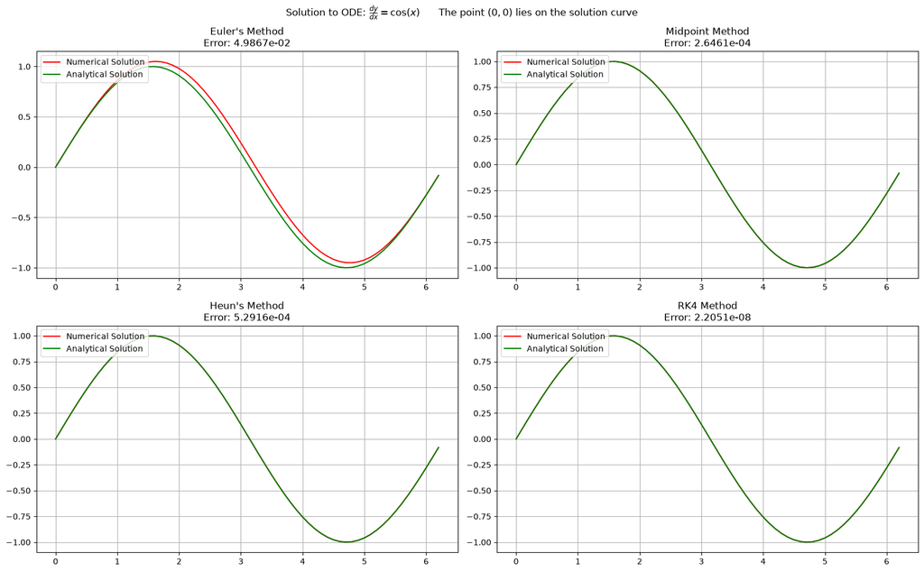

```python
func = lambda x, y: np.cos(x)
sol = lambda x: np.sin(x)
a = 0
b = 2*np.pi
h = 0.1
data = {
    "func": func,
    "initial": 0
}
fig, axes = plt.subplots(2, 2, figsize=(16, 10))

plt.suptitle(r"$\text{Solution to ODE: }\frac{dy}{dx}=\cos(x)\qquad\text{The point }(0, 0)\text{ lies on the solution curve}$")

x, y = ivp.euler_method(a, b, h, **data)
axes[0, 0].set_title(f"Euler's Method\nError: {np.mean(np.abs(y-sol(x))):.4e}")
axes[0, 0].plot(x, y, color="red", label="Numerical Solution")
axes[0, 0].plot(x, sol(x), color="green", label="Analytical Solution")
axes[0, 0].grid()
axes[0, 0].legend(loc="upper left")

x, y = ivp.midpoint_method(a, b, h, **data)
axes[0, 1].set_title(f"Midpoint Method\nError: {np.mean(np.abs(y-sol(x))):.4e}")
axes[0, 1].plot(x, y, color="red", label="Numerical Solution")
axes[0, 1].plot(x, sol(x), color="green", label="Analytical Solution")
axes[0, 1].grid()
axes[0, 1].legend(loc="upper left")

x, y = ivp.heun_method(a, b, h, **data)
axes[1, 0].set_title(f"Heun's Method\nError: {np.mean(np.abs(y-sol(x))):.4e}")
axes[1, 0].plot(x, y, color="red", label="Numerical Solution")
axes[1, 0].plot(x, sol(x), color="green", label="Analytical Solution")
axes[1, 0].grid()
axes[1, 0].legend(loc="upper left")

x, y = ivp.rk4(a, b, h, **data)
axes[1, 1].set_title(f"RK4 Method\nError: {np.mean(np.abs(y-sol(x))):.4e}")
axes[1, 1].plot(x, y, color="red", label="Numerical Solution")
axes[1, 1].plot(x, sol(x), color="green", label="Analytical Solution")
axes[1, 1].grid()
axes[1, 1].legend(loc="upper left")

plt.tight_layout()
plt.show()
```

## Solving second order ODEs:

A second order ODE is assumed to be of format: $\frac{d^2y}{dx^2}+P(x, y)\frac{dy}{dx}=Q(x, y)$

To solve a second order ODE, we have to find $\frac{dy}{dx}$ using $\frac{d^2y}{dx^2}$, then use it to find $y$.

The algorithm becomes:

1. Find $\frac{d^2y}{dx^2}$ at the point $a+ih$
2. Using $\frac{d^2y}{dx^2}$ obtained in previous step, find $\frac{dy}{dx}$.
3. Using $\frac{dy}{dx}$ obtained in previous step, find $y$.

Using this simple algorithm we can find solution to second order ODEs. We will need to seed in the initial value of $y$ and $\frac{dy}{dx}$.

## An example:

We will consider the simple second order ODE: $\frac{d^2y}{dx^2}-3\frac{dy}{dx}=x-2y$, in the region $(0, 2)$, with $y(0)=0\qquad y'(0)=0$ with stepsize $0.1$.

The analytical solution is: $y=\frac{e^{2x}}{4}-e^x+\frac{x}{2}+\frac{3}{4}$

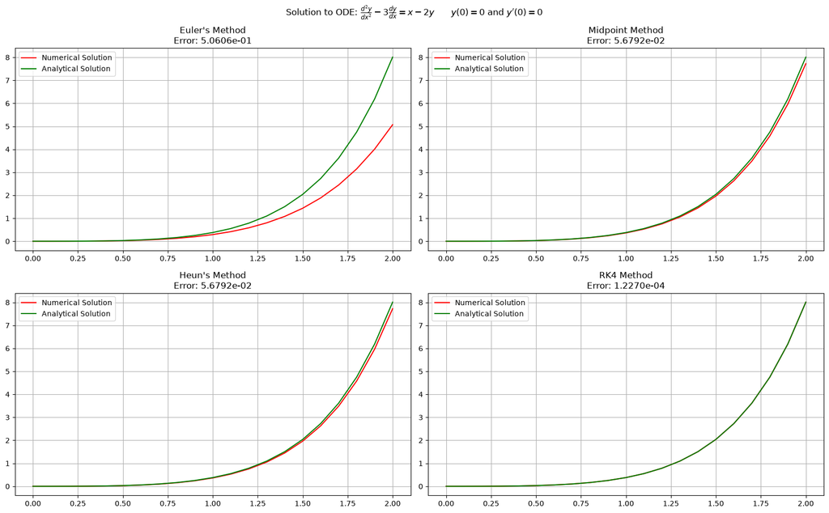

```python
p = lambda x, y: -3
q = lambda x, y: x-2*y
sol = lambda x: 0.25*np.exp(2*x)-np.exp(x)+0.5*x+0.75
a = 0
b = 2
h = 0.1
data = {
    "p": p,
    "q": q,
    "initial": 0,
    "initial_slope": 0
}

fig, axes = plt.subplots(2, 2, figsize=(16, 10))

plt.suptitle(r"$\text{Solution to ODE: }\frac{d^2y}{dx^2}-3\frac{dy}{dx}=x-2y\qquady(0)=0\text{ and }y'(0)=0$")

x, y = ivp.euler_method(a, b, h, **data)
axes[0, 0].set_title(f"Euler's Method\nError: {np.mean(np.abs(y-sol(x))):.4e}")
axes[0, 0].plot(x, y, color="red", label="Numerical Solution")
axes[0, 0].plot(x, sol(x), color="green", label="Analytical Solution")
axes[0, 0].grid()
axes[0, 0].legend(loc="upper left")

x, y = ivp.midpoint_method(a, b, h, **data)
axes[0, 1].set_title(f"Midpoint Method\nError: {np.mean(np.abs(y-sol(x))):.4e}")
axes[0, 1].plot(x, y, color="red", label="Numerical Solution")
axes[0, 1].plot(x, sol(x), color="green", label="Analytical Solution")
axes[0, 1].grid()
axes[0, 1].legend(loc="upper left")

x, y = ivp.heun_method(a, b, h, **data)
axes[1, 0].set_title(f"Heun's Method\nError: {np.mean(np.abs(y-sol(x))):.4e}")
axes[1, 0].plot(x, y, color="red", label="Numerical Solution")
axes[1, 0].plot(x, sol(x), color="green", label="Analytical Solution")
axes[1, 0].grid()
axes[1, 0].legend(loc="upper left")

x, y = ivp.rk4(a, b, h, **data)
axes[1, 1].set_title(f"RK4 Method\nError: {np.mean(np.abs(y-sol(x))):.4e}")
axes[1, 1].plot(x, y, color="red", label="Numerical Solution")
axes[1, 1].plot(x, sol(x), color="green", label="Analytical Solution")
axes[1, 1].grid()
axes[1, 1].legend(loc="upper left")

plt.tight_layout()
plt.show()
```

## Solving ODEs using states:

The above methods are suitable for solving equations like: $$ \frac{dy}{dx}=f(x, y)\qquad\text{and}\qquad\frac{d^2y}{dx^2}=f\left(x, y, \frac{dy}{dx}\right) $$ But they cannot solve coupled systems or higher order ODEs without modification as each case needs. Hence we need something more generalizable.

This generalization is possible because of vectors and their calculus!

Suppose there is a coupled system such that: $$ \frac{dy_1}{dt}=f_1(t, y_1, y_2, \ldots, y_n)\qquad\frac{dy_2}{dt}=f_2(t, y_1, y_2, \ldots, y_n)\qquad\cdots\qquad\frac{dy_n}{dt}=f_n(t, y_1, y_2, \ldots, y_n) $$ To solve this system, we first convert it into a vector: $$\begin{align*} &\vec{r}(t)=\langle y_1(t), y_2(t), \ldots, y_n(t) \rangle\\ &\frac{d\vec{r}}{dt}=\langle y_1'(t), y_2'(t), \ldots, y_n'(t) \rangle\\ &\vec{r}'(t)=\langle f_1(t, \vec{r}), f_2(t, \vec{r}), \ldots, f_n(t, \vec{r}) \rangle\\ &\text{Now we just have to follow the general procedure we did above:}\\ &\text{Since this is an IVP, we know the area of interest is from }t=a\text{ to }t=b\\ &\text{Also, }\vec{r}(a)=\langle y_1(a), y_2(a), \ldots, y_n(a) \rangle\\ &\text{Next we divide the interval into }N\text{ equal parts with stepsize }h\\ &\text{Now with this knowledge, we approximate the value of }\vec{r}(a+h)\\ &\vec{r}(a+h)=\vec{r}+h\vec{r}'(a)\\ &\begin{bmatrix} y_1(a+h)\\ y_2(a+h)\\ \vdots\\ y_n(a+h) \end{bmatrix}=\begin{bmatrix} y_1(a)\\ y_2(a)\\ \vdots\\ y_n(a) \end{bmatrix}+h\begin{bmatrix} f_1(a, \vec{r}(a))\\ f_2(a, \vec{r}(a))\\ \vdots\\ f_n(a, \vec{r}(a)) \end{bmatrix}\\ &\begin{bmatrix} y_1(a+h)\\ y_2(a+h)\\ \vdots\\ y_n(a+h) \end{bmatrix}=\begin{bmatrix} y_1(a)+h\,f_1(a, \vec{r}(a))\\ y_2(a)+h\,f_2(a, \vec{r}(a))\\ \vdots\\ y_n(a)+h\,f_n(a, \vec{r}(a)) \end{bmatrix}\\ &\text{This is exactly what we expect for }y_i(a+h)\text{. Using states we could do this in fewer steps and simple formula.}\\ &\text{We can make a table for this:}\\ &\begin{array} &x&&y\\ \hline a&&\vec{r}(a)\\ a+h&&\vec{r}(a)+h\vec{r}'(a)\\ a+2h&&\vec{r}(a+h)+h\vec{r}'(a+h)\\ \vdots&&\vdots\\ a+Nh=b&&\vec{r}(a+(N-1)h)+h\vec{r}'(a+(N-1)h) \end{array}\\ &\text{The above table gives the table of values for Euler's method. We can easily construct this for other methods as well, but I wish to point towards something more interesting.}\\ &\text{With the previous implementations, we were forced to manually comeback to update it step by step, but here just vector addition does this work for us.}\\ &\text{More surprisingly we can solve second order ODEs as well!}\\ &\text{Assume a second order ODE:}\\ &\frac{d^2y}{dx^2}=f\left(x, y, \frac{dy}{dx}\right)\\ &\text{We decompose this into two states such that:}\\ &v=\frac{dy}{dx}\implies\frac{dv}{dx}=f(x, y, v)\\ &\text{Now with }\vec{r}=\langle y, v \rangle\\ &\frac{d\vec{r}}{dx}=\left\langle \frac{dy}{dx}, \frac{dv}{dx} \right\rangle\\ &\frac{d\vec{r}}{dx}=\langle v, f(x, \vec{r}) \rangle\\ &\text{Now by just doing }\vec{r}_{i+1}=\vec{r}_i+h\frac{d\vec{r}}{dx}\qquad\forall 0\leq i < N\quad\text{ we will get the solution for second order ODE.}\\ &\text{Similarly we can extend this over to higher order ODEs too.}\\ &\text{One thing that I am fascinated is by how it just reduces to }\vec{r}_{i+1}=\vec{r}_i+h\frac{d\vec{r}}{dx}\\ &\text{In the earlier version of this project, I was travelling to and fro for updating states at every step.} \end{align*}$$

## An example:

We will consider the simple coupled system: $\frac{dy}{dt}=\frac{x}{2}$ and $\frac{dx}{dt}=\frac{y}{8}$, in the region $t\in(0, 4)$ and stepsize $0.01$ with the condition that at $t=0$, $x=1$ and $y=0$.

The analytical solution is: $x(t)=\cosh(\frac{t}{4})\qquad y(t)=2\sinh(\frac{t}{4})$

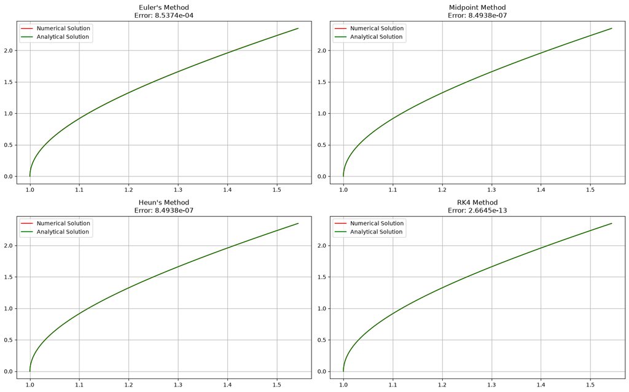

```python
def func(t, state):
    x, y = state[0], state[1]
    return np.array([
        y/8,
        x/2
    ])

a = 0
b = 4
h = 0.01
initial_state = np.array([1, 0])

fig, axes = plt.subplots(2, 2, figsize=(16, 10))

t, solution = ivp.state_euler_method(a, b, h, func, initial_state)
x, y = solution[0], solution[1]
axes[0, 0].set_title(f"Euler's Method\nError: {np.mean(np.abs(solution - np.vstack((np.cosh(t/4), 2*np.sinh(t/4))))):.4e}")
axes[0, 0].plot(x, y, color="red", label="Numerical Solution")
axes[0, 0].plot(np.cosh(t/4), 2*np.sinh(t/4), color="green", label="Analytical Solution")
axes[0, 0].grid()
axes[0, 0].legend(loc="upper left")

t, solution = ivp.state_midpoint_method(a, b, h, func, initial_state)
x, y = solution[0], solution[1]
axes[0, 1].set_title(f"Midpoint Method\nError: {np.mean(np.abs(solution - np.vstack((np.cosh(t/4), 2*np.sinh(t/4))))):.4e}")
axes[0, 1].plot(x, y, color="red", label="Numerical Solution")
axes[0, 1].plot(np.cosh(t/4), 2*np.sinh(t/4), color="green", label="Analytical Solution")
axes[0, 1].grid()
axes[0, 1].legend(loc="upper left")

t, solution = ivp.state_heun_method(a, b, h, func, initial_state)
x, y = solution[0], solution[1]
axes[1, 0].set_title(f"Heun's Method\nError: {np.mean(np.abs(solution - np.vstack((np.cosh(t/4), 2*np.sinh(t/4))))):.4e}")
axes[1, 0].plot(x, y, color="red", label="Numerical Solution")
axes[1, 0].plot(np.cosh(t/4), 2*np.sinh(t/4), color="green", label="Analytical Solution")
axes[1, 0].grid()
axes[1, 0].legend(loc="upper left")

t, solution = ivp.state_rk4(a, b, h, func, initial_state)
x, y = solution[0], solution[1]
axes[1, 1].set_title(f"RK4 Method\nError: {np.mean(np.abs(solution - np.vstack((np.cosh(t/4), 2*np.sinh(t/4))))):.4e}")
axes[1, 1].plot(x, y, color="red", label="Numerical Solution")
axes[1, 1].plot(np.cosh(t/4), 2*np.sinh(t/4), color="green", label="Analytical Solution")
axes[1, 1].grid()
axes[1, 1].legend(loc="upper left")

plt.tight_layout()
plt.show()
```

Let us also solve a second order coupled ODE: $$ \frac{d^2y}{dt^2}+4y=0\qquad\frac{d^2x}{dt^2}+x=0 $$ With $x(0)=2$ and $x'(0)=0$, $y(0)=0$ and $y'(0)=4$ and stepsize $0.01$ for $t\in(0, 2\pi)$

The analytical solution is: $x(t)=2\cos(t)\qquad y(t)=2\sin(2t)$

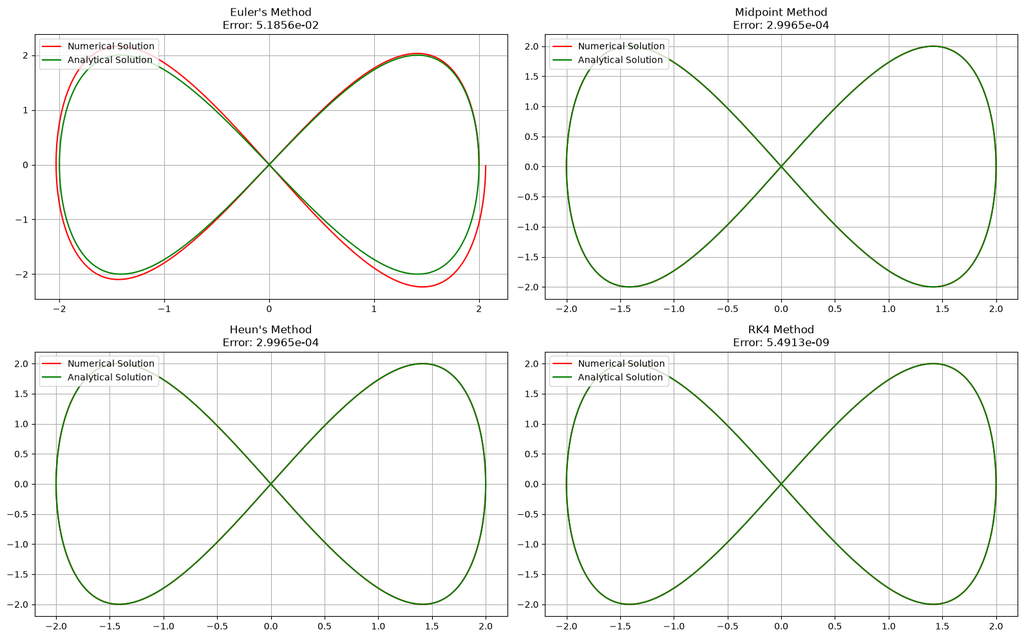

```python
def func(t, state):
    x, dx, y, dy = state[0], state[1], state[2], state[3]
    return np.array([
        dx,
        -x,
        dy,
        -4*y
    ])

a = 0
b = 2*np.pi
h = 0.01
initial_state = np.array([2, 0, 0, 4])

fig, axes = plt.subplots(2, 2, figsize=(16, 10))

t, solution = ivp.state_euler_method(a, b, h, func, initial_state)
x, y = solution[0], solution[2]
axes[0, 0].set_title(f"Euler's Method\nError: {np.mean(np.abs(solution[[0, 2]] - np.vstack((2*np.cos(t), 2*np.sin(2*t))))):.4e}")
axes[0, 0].plot(x, y, color="red", label="Numerical Solution")
axes[0, 0].plot(2*np.cos(t), 2*np.sin(2*t), color="green", label="Analytical Solution")
axes[0, 0].grid()
axes[0, 0].legend(loc="upper left")

t, solution = ivp.state_midpoint_method(a, b, h, func, initial_state)
x, y = solution[0], solution[2]
axes[0, 1].set_title(f"Midpoint Method\nError: {np.mean(np.abs(solution[[0, 2]] - np.vstack((2*np.cos(t), 2*np.sin(2*t))))):.4e}")
axes[0, 1].plot(x, y, color="red", label="Numerical Solution")
axes[0, 1].plot(2*np.cos(t), 2*np.sin(2*t), color="green", label="Analytical Solution")
axes[0, 1].grid()
axes[0, 1].legend(loc="upper left")

t, solution = ivp.state_heun_method(a, b, h, func, initial_state)
x, y = solution[0], solution[2]
axes[1, 0].set_title(f"Heun's Method\nError: {np.mean(np.abs(solution[[0, 2]] - np.vstack((2*np.cos(t), 2*np.sin(2*t))))):.4e}")
axes[1, 0].plot(x, y, color="red", label="Numerical Solution")
axes[1, 0].plot(2*np.cos(t), 2*np.sin(2*t), color="green", label="Analytical Solution")
axes[1, 0].grid()
axes[1, 0].legend(loc="upper left")

t, solution = ivp.state_rk4(a, b, h, func, initial_state)
x, y = solution[0], solution[2]
axes[1, 1].set_title(f"RK4 Method\nError: {np.mean(np.abs(solution[[0, 2]] - np.vstack((2*np.cos(t), 2*np.sin(2*t))))):.4e}")
axes[1, 1].plot(x, y, color="red", label="Numerical Solution")
axes[1, 1].plot(2*np.cos(t), 2*np.sin(2*t), color="green", label="Analytical Solution")
axes[1, 1].grid()
axes[1, 1].legend(loc="upper left")

plt.tight_layout()
plt.show()
```

The implementation in `state_euler_method` is explicit, due to this energy does not gets conserved and in large intervals it goes out of control.

Other methods have a local error of order $\mathcal{O}(h^3), \mathcal{O}(h^3)\text{ and }\mathcal{O}(h^5)$ respectively, due to this they stay close to the analytical solution.

With coupled system, how could we forget Lorenz Attractor and Double Pendulum? Double Pendulum requires a animation, which I will keep in the project and on [GitHub Pages](https://ojasrane.github.io/Ordinary-Differential-Equations/en/animations/) associated with this project. It will also have animation for Lorenz Attractor.

Here we will take the systems: $$ \dot{x}=10(y-x)\qquad\dot{y}=x(28-z)-y\qquad\dot{z}=xy-\frac{8}{3}z $$ With initial conditions: $x_0=0\quad y_0=1\quad z_0=0$ and $x_0=0.1\quad y_0=1\quad z_0=0$

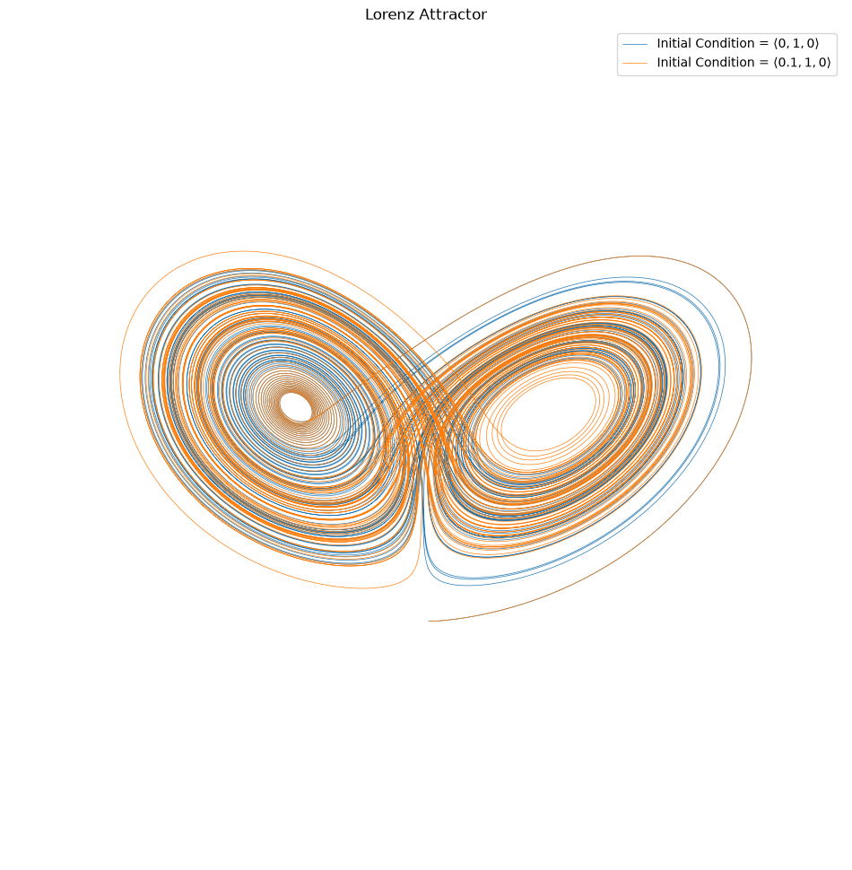

```python
sigma = 10
rho = 28
beta = 8/3

def func(t, state):
    x, y, z = state[0], state[1], state[2]
    return np.array([
        sigma*(y-x),
        x*(rho-z)-y,
        x*y-beta*z
    ])

a = 0
b = 100
h = 0.001

fig = plt.figure(figsize=(12, 16))
ax = fig.add_subplot(projection="3d")

ax.set_title("Lorenz Attractor")

t, solution1 = ivp.state_rk4(a, b, h, func, np.array([0, 1, 0]))
ax.plot(solution1[0], solution1[1], solution1[2], label=r"$\text{Initial Condition = }\langle 0, 1, 0 \rangle$", lw=0.5)

t, solution2 = ivp.state_rk4(a, b, h, func, np.array([0.1, 1, 0]))
ax.plot(solution2[0], solution2[1], solution2[2], label=r"$\text{Initial Condition = }\langle 0.1, 1, 0 \rangle$", lw=0.5)

ax.axis("off")
ax.legend(loc="upper right")
ax.view_init(elev=10, azim=-45, roll=0)
plt.show()
```

This is chaos. Both had nearly same initial condition, but still the output differed so much.